# Exploring #backOfaFagPacket scenarios for a residential dwellings Carbon Tax

Southampton as a case study

Ben Anderson

Last run at: 2020-11-11 18:49:23

# 1 fridayFagPackets

Numbers that could have been done on the back of one and should probably come with a similar health warning…

> Find out [more](https://dataknut.github.io/fridayFagPackets/).

# 2 Preamble

There’s a lot of talk about Carbon Taxes right now and some early signs that the UK Government will apply them to (larger) businesses post-Brexit (i.e. post-ETS). There is currently not much noise on the idea of applying them to households but it is always a possibility given the acceptance of using tax-based incentives to attempt to suppress the consumption of bad stuff. Think tobacco, alcohol and sugar.

But what if we did? How much would it raise and from whom?

There is no simple answer to this hypothetical question since it depends what [scope of emissions](https://www.carbontrust.com/resources/briefing-what-are-scope-3-emissions) we consider, in what detail and our assumptions of taxation levels per kg of CO2. Broadly speaking the scopes are:

- Scope 1 – All direct emissions caused by burning something (gas, oil, wood, coal etc);
- Scope 2 - Indirect emissions from electricity purchased and used - the carbon intensity of these (kg CO2/kWh) depends on how it is generated and also, of course, on which tariff you have. A 100% renewable electrons tariff will have a carbon intensity of ~0. If you have a ‘normal’ tariff you will just have to take what the [grid offers](https://www.carbonintensity.org.uk/);
- Scope 3 - All Other Indirect Emissions from things you do - e.g. the things you buy (food, clothes, gadgets etc etc)

Estimating the emissions from [Scope 3](https://www.carbontrust.com/resources/briefing-what-are-scope-3-emissions) is [notably difficult](https://www.sciencedirect.com/science/article/pii/S0921800913000980) so for now we’re going to make a #backOfaFagPacket estimate of the residential emissions from Scopes 1 and 2 in Southampton and see what a Carbon Tax applied to these emissions would look like.

# 3 How?

```r
msoaDT <- data.table::fread(here::here("data", "sotonMSOAdata.csv"))
```

In an ideal world we would know the fuel (gas, oil, coal, wood, electricity) inputs per year for each dwelling/household in Southampton together with details of how these are used (some methods release more carbon dioxide than others). But we don’t. Once the [Smart Energy Research Laboratory](https://serl.ac.uk) really gets going we will have kWh gas and electricity data for a representative sample of British homes (but not a larger enough sample from Southampton to be helpful here). But not yet and even then it may not include other fuels… Other research has used [UK data on family expenditures on Scope 1-3 ‘consumption’](https://www.sciencedirect.com/science/article/pii/S0921800913000980) but we can’t apply that directly to Southampton.

So what to do? There are a number of possible approaches and we’re going to compare two of them:

- Use the most recent [BEIS sub-national electricity and gas demand data](https://www.gov.uk/government/publications/regional-energy-data-guidance-note) for ~30 local areas (MSOAs) in Southampton and estimate the CO2 emissions at MSOA and (by summing them) at City level;
- Use the modelled CO2 emissions per dwelling data in the [Energy Performance Certificate data](https://epc.opendatacommunities.org/docs/guidance) for Southampton to do the same thing. Modelling carbon emissions from the built form is [a well known](https://www.sciencedirect.com/science/article/pii/S2212609015000333) and much-criticised approach. Nevertheless it provides data suitable for a #backOfaFagPacket estimate.

Unfortunately there are problems with both which we have reported in excessive detail elsewhere. In summary:

- the most recent BEIS data is from 2018. This will not include dwellings and households that did not exist (new builds) at that time, nor account for any building stock improvements since then;
- the EPC records are incomplete since an EPC is only created when a dwelling is rented or sold (since 2007);
- the EPC data have some oddities that mean we have to filter out a few ‘impossible’ values.

This means that both datasets are imperfect for the job. But they’re about as close as we can currently get.

So with the usual #backOfaFagPacket health warning, let’s try.

# 4 Current estimated annual CO2 emmisions

In this #fridayFagPacket we’re going to use these datasets to estimate the annual CO2 emissions at MSOA level for Southampton using:

- BEIS observed data
- aggregated EPC data

Obviously the EPC-derived totals will not be the total CO2 emissions for **all** Southampton properties since we know not all dwellings are represented in the EPC data (see above and in more detail).

Note that we can also use the EPC estimated CO2 emissions data to look at dwelling level patterns if a Carbon Tax was applied. We leave that for a future #fridayFagPacket.

## 4.1 Method

To calculate the MSOA level estimates from the BEIS data we need to apply conversion factors that convert the kWh numbers we have to CO2 emissions. We use the following:

```r
elecCF <- 200 # g CO2e/kWh https://www.icax.co.uk/Grid_Carbon_Factors.html
gasCF <- 215 # g CO2e/kWh https://www.icax.co.uk/Carbon_Emissions_Calculator.html
```

- electricity: 200 g CO2e/kWh
- gas: 215 g CO2e/kWh

Clearly if we change these assumptions then we change the results…

For the EPC we just use the estimated CO2 values - although we should note that these are based on [‘old’ electricity grid carbon intensity values](https://www.passivhaustrust.org.uk/guidance_detail.php?gId=44) and since the EPC data does not provide gas and electricity kWh data separately, we cannot correct it.

```r
msoaDT[, sumBEIS_gCO2 := (beisElecMWh*1000)*elecCF + (beisGasMWh*1000)*gasCF] # calculate via g & kWh
msoaDT[, sumBEIS_tCO2 := sumBEIS_gCO2/1000000] # tonnes
```

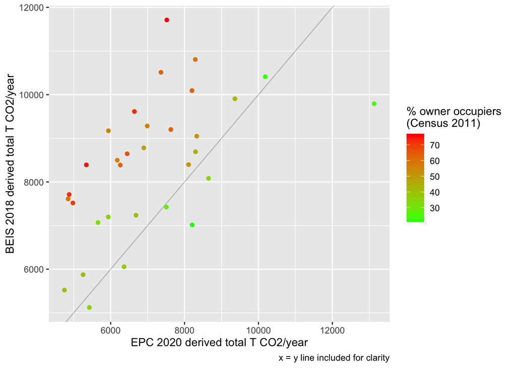

Figure 4.1: Home energy related CO2 emissions comparison for each MSOA in Southampton

```r
ggplot2::ggplot(msoaDT, aes(x = sumEPC_tCO2,
                       y = sumBEIS_tCO2,
                       colour = round(ownerOcc_pc))) +
  geom_abline(alpha = 0.2, slope=1, intercept=0) +
  geom_point() +
  scale_color_continuous(name = "% owner occupiers \n(Census 2011)", high = "red", low = "green") +
  #theme(legend.position = "bottom") +
  labs(x = "EPC 2020 derived total T CO2/year",
       y = "BEIS 2018 derived total T CO2/year",
       caption = "x = y line included for clarity")
```

```r
#outlier <- t[sumEpcMWh > 70000]

msoaDT[, tCO2_diff_pc := 100 * ((sumBEIS_tCO2 - sumEPC_tCO2)/sumBEIS_tCO2)]
message("Distribution of % difference from BEIS derived value")
```

```
## Distribution of % difference from BEIS derived value
```

```r
summary(msoaDT$tCO2_diff_pc)
```

```
##    Min. 1st Qu.  Median    Mean 3rd Qu.    Max.
## -34.089   4.248  18.134  15.049  27.962  36.771
```

Figure 4.1 shows that the BEIS derived estimates are generally larger than the EPC derived totals (mean difference = 15%) and in one case 36.8% larger.

There are a number of potential reasons for this which are discussed in more detail elsewhere but relate to:

- inclusion of all energy use in the BEIS data (not just hot water, heating and lighting)
- incomplete coverage of dwellings by the EPC data
- dwellings missing from the BEIS 2018 data which are now present in the EPC data (new builds)

```r
t <- msoaDT[, .(sumEPC_tCO2 = sum(sumEPC_tCO2),
            sumBEIS_tCO2 = sum(sumBEIS_tCO2),
            nMSOAs = .N), keyby = .(LAName)]
t[, pc_diff :=  100 * ((sumBEIS_tCO2 - sumEPC_tCO2)/sumBEIS_tCO2)]

kableExtra::kable(t, caption = "Total domestic energy related CO2 emissions for Southampton (tonnes)") %>%
  kable_styling()
```

Table 4.1: Total domestic energy related CO2 emissions for Southampton (tonnes)

| LAName | sumEPC_tCO2 | sumBEIS_tCO2 | nMSOAs | pc_diff |
| --- | --- | --- | --- | --- |
| Southampton | 226263.3 | 268800.5 | 32 | 15.82481 |

With this in mind the total t CO2e values shown in Table 4.1 shows the BEIS figures to be around 16% higher than those estimated using the EPC data. The figure of 268,801 is very close to that calculated via the [Southampton Green City Tracker](https://soton-uni.maps.arcgis.com/apps/opsdashboard/index.html#/c3041574a8794439a39045b7ee341cfa) for Domestic Carbon Emissions in 2018.

# 5 Carbon Tax Scenarios

We now use these MSOA level estimates to calculate the tax liability of these emissions if:

- there is no change to carbon intensity - i.e. the current baseline. In this case we can use both the BEIS and EPC derived data although they will simply differ by the same % as reported above
- the carbon intensity of electricity falls to [100 gCO2/kWh](https://www.carbonintensity.org.uk/) by 2030 (an [entirely feasible level](https://www.nationalgrideso.com/future-energy/future-energy-scenarios/fes-2020-documents)) and we assume no changes to the carbon intensity of gas. In this case we can only use the BEIS data since we are unable to separate fuel source in the EPC data.

In all cases we assume:

- no emissions allowances (unlike the ETS and also [current UK government proposals](https://assets.publishing.service.gov.uk/government/uploads/system/uploads/attachment_data/file/828824/Carbon_Emissions_Tax_-_Technical_Note__1_.pdf))
- [Carbon tax rate of £16/TCO2](https://assets.publishing.service.gov.uk/government/uploads/system/uploads/attachment_data/file/828824/Carbon_Emissions_Tax_-_Technical_Note__1_.pdf) (currently only proposed for [businesses](https://www.gov.uk/government/publications/changes-to-tax-provisions-for-carbon-emissions-tax/changes-to-tax-provisions-for-carbon-emissions-tax))
- no other behavioural or building fabric related changes (highly unlikely)

## 5.1 No change to carbon intensity

Applying these rates enables us to calculate the Southampton and MSOA level Carbon Tax liability of households via the EPC and BEIS observed energy consumption methods.

```r
carbonTaxRate <- 16

msoaDT[, ct_BEIS := sumBEIS_tCO2 * carbonTaxRate]
msoaDT[, ct_EPCs := sumEPC_tCO2 * carbonTaxRate]

t <- msoaDT[, .(CarbonTaxBEIS_GBP = prettyNum(sum(ct_BEIS), big.mark = ","),
                      CarbonTaxEPCs_GBP = prettyNum(sum(ct_EPCs), big.mark = ",")),
                  keyby = .(LAName)]

kableExtra::kable(t, caption = "Estimated baseline Carbon Tax liability for Southampton households/properties") %>%
  kable_styling()
```

Table 5.1: Estimated baseline Carbon Tax liability for Southampton households/properties

| LAName | CarbonTaxBEIS_GBP | CarbonTaxEPCs_GBP |
| --- | --- | --- |
| Southampton | 4,300,808 | 3,620,213 |

```r
ct_perHH <- sum(msoaDT$ct_BEIS)/sum(msoaDT$nHHs_tenure)
```

As we would expect the values are relatively close due to the similar total emissions values estimated above. Using the BEIS estimate this works out to a mean of ~ £43.77 per household per year. Not a lot. Would you try to de-carbonise your energy supply to try to reduce a Carbon Tax liability of that scale?

```r
councilTax_perHH <- 102000000/sum(msoaDT$nHHs_tenure)
```

For context, Southampton City Council project a `Council Tax Requirement` of £102m in Council Tax in [2020-2021](https://www.southampton.gov.uk/council-tax/information/how-much-we-spend.aspx). That’s a mean of ~ £ 1038 per household per year…

However, as we would expect given Figure 4.1, if we look at the values by MSOA (Figure 5.1), we find that values differ quite substantially between the methods depending on the levels of EPC records (or missing households - see above) that we are likely to have.

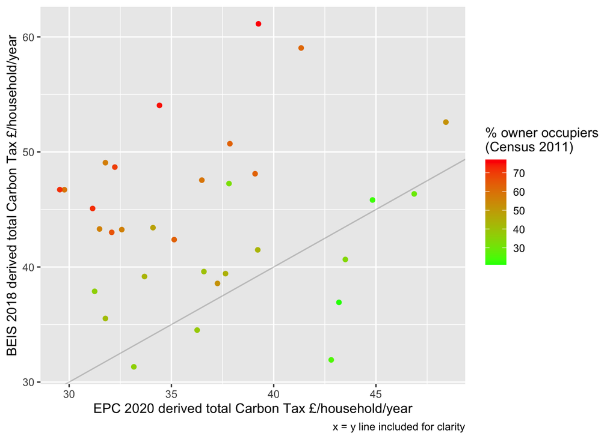

```r
ggplot2::ggplot(msoaDT, aes(x = ct_EPCs/nHHs_tenure,
                       y = ct_BEIS/nHHs_tenure,
                       colour = round(ownerOcc_pc))) +
  geom_abline(alpha = 0.2, slope=1, intercept=0) +
  geom_point() +
  scale_color_continuous(name = "% owner occupiers \n(Census 2011)", high = "red", low = "green") +
  #theme(legend.position = "bottom") +
  labs(x = "EPC 2020 derived total Carbon Tax £/household/year",
       y = "BEIS 2018 derived total Carbon Tax £/household/year",
       caption = "x = y line included for clarity")
```

```r
#outlier <- t[sumEpcMWh > 70000]
```

Perhaps of more interest however is the relationship between estimated Carbon Tax £ per household and levels of deprivation. Figure 5.2 shows the estimated mean Carbon Tax per household (in £ per year using Census 2011 household counts) for each MSOA against the proportion of households in the MSOA who do not suffer from any dimension of deprivation as defined by the English [Indices of Multiple Deprivation](https://www.nomisweb.co.uk/census/2011/qs119ew). As we can see the higher the proportion of households with no deprivation, the higher the mean household Carbon Tax. This suggests that a Carbon Tax will be progressive - those who pay the most are likely to be those who use more energy and thus are likely to be those who can afford to do so. Interestingly the BEIS-derived estimates show a much stronger trend than the EPC data which relies solely on building fabric model-based estimates of carbon emissions.

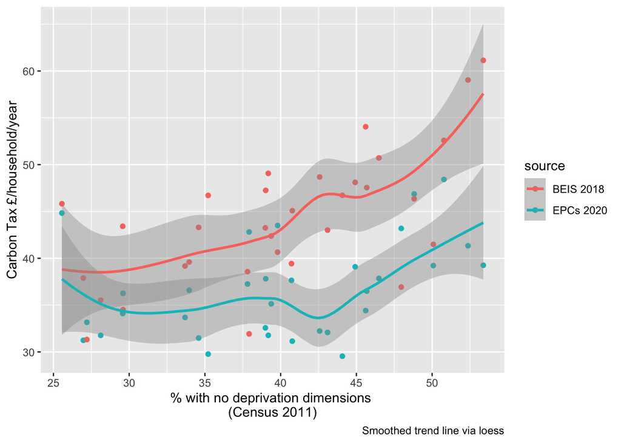

Figure 5.2: Carbon Tax comparison by MSOA deprivation levels

```r
epcBaseline <- msoaDT[, .(MSOACode, ctSum = ct_EPCs, nHHs_tenure, dep0_pc)]
epcBaseline[, source := "EPCs 2020"]
beisBaseline <- msoaDT[, .(MSOACode, ctSum = ct_BEIS, nHHs_tenure, dep0_pc)]
beisBaseline[, source := "BEIS 2018"]

plotDT <- rbind(epcBaseline,beisBaseline)

ggplot2::ggplot(plotDT, aes(x = dep0_pc, y = ctSum/nHHs_tenure, colour = source)) +
  geom_point() +
  geom_smooth() +
  #theme(legend.position = "bottom") +
  labs(x = "% with no deprivation dimensions \n(Census 2011)",
       y = "Carbon Tax £/household/year",
       caption = "Smoothed trend line via loess")
```

```r
#outlier <- t[sumEpcMWh > 70000]
```

## 5.2 Reducing electricity carbon intensity

```r
elecCF_scen1 <- 100
```

Under this scenario we repeat the preceding analysis but use:

- electricity: 100 g CO2e/kWh
  - gas: 215 g CO2e/kWh

```r
msoaDT[, sumBEIS_gCO2_scen1 := (beisElecMWh*1000)*elecCF_scen1 + (beisGasMWh*1000)*gasCF] # calculate via g & kWh
msoaDT[, sumBEIS_tCO2_scen1 := sumBEIS_gCO2_scen1/1000000] # tonnes

msoaDT[, ct_BEIS_scen1 := sumBEIS_tCO2_scen1 * 16]

t <- msoaDT[, .(Baseline = sum(ct_BEIS),
                Scenario_1 = sum(ct_BEIS_scen1)),
                  keyby = .(LAName)]
t[, reduction_pc := round(100*(1-(Scenario_1/Baseline)))]

kableExtra::kable(t, caption = "Estimated Carbon Tax liability for Southampton households/properties under Scenario 1") %>%
  kable_styling()
```

Table 5.2: Estimated Carbon Tax liability for Southampton households/properties under Scenario 1

| LAName | Baseline | Scenario_1 | reduction_pc |
| --- | --- | --- | --- |
| Southampton | 4300808 | 3687381 | 14 |

Figure 5.3 shows the estimated mean annual Carbon Tax per household (£ per household per year) per MSOA under the new scenario against the proportion of households in the MSOA who do not suffer from any dimension of deprivation as defined by the English [Indices of Multiple Deprivation](https://www.nomisweb.co.uk/census/2011/qs119ew). It also shows the original BEIS baseline for comparison. As we can see the shapes of the curves are similar but with an overall reduction. There do not appear to be any particular advantages for areas with higher or lower deprivation levels.

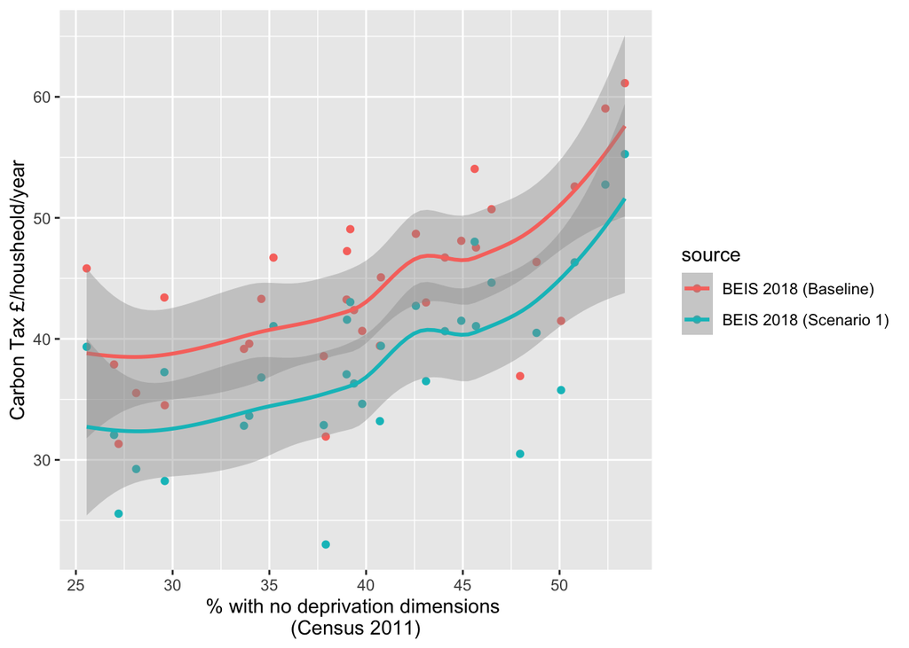

Figure 5.3: Carbon tax by deprivation under Scenario 1

```r
scen1 <- msoaDT[, .(MSOACode, ctSum = ct_BEIS_scen1, dep0_pc,nHHs_tenure)]
scen1[, source := "BEIS 2018 (Scenario 1)"]
beisBaseline[, source := "BEIS 2018 (Baseline)"]
plotDT <- rbind(beisBaseline, scen1)

ggplot2::ggplot(plotDT, aes(x = dep0_pc, y = ctSum/nHHs_tenure, colour = source)) +
  geom_point() +
  geom_smooth() +
  #theme(legend.position = "bottom") +
  labs(x = "% with no deprivation dimensions \n(Census 2011)",
       y = "Carbon Tax £/housheold/year")
```

```r
#outlier <- t[sumEpcMWh > 70000]
```

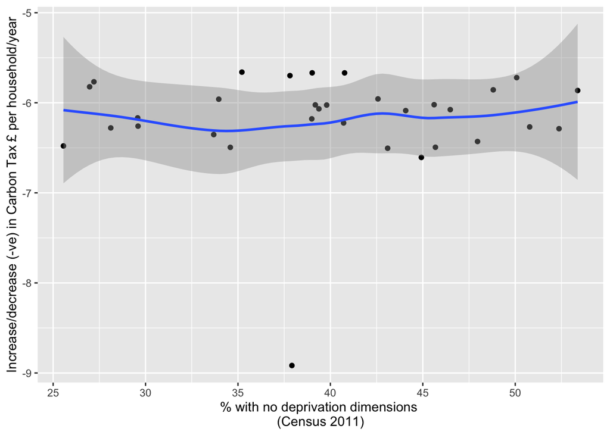

Figure 5.4: Carbon tax by deprivation under Scenario 1

```r
setkey(beisBaseline, MSOACode)
setkey(scen1, MSOACode)
plotDT <- beisBaseline[scen1]
plotDT[, delta := i.ctSum-ctSum]

ggplot2::ggplot(plotDT, aes(x = dep0_pc, y = delta/nHHs_tenure)) +
  geom_point() +
  geom_smooth() +
  #theme(legend.position = "bottom") +
  labs(x = "% with no deprivation dimensions \n(Census 2011)",
       y = "Increase/decrease (-ve) in Carbon Tax £ per household/year")
```

```r
outlier <- plotDT[delta < -40000]
outlier$MSOACode
```

```
## [1] "E02003577"
```

However if we analyse the total change by MSOA (5.4) we see that one area (E02003577) shows a marked reduction. We have seen this area before - it has the highest electricity demand so no surprises there.

## 5.3 But are we missing the point?

Notwithstanding the caveats, we can get a sense of this from the EPC data if we use the modelled CO2 emissions per dwelling and multiply by our Carbon Tax rate (£16 per tonne/year).

```r
epcDT <- data.table::fread(path.expand("~/data/EW_epc/domestic-E06000045-Southampton/EPCs_liveFinalClean.csv.gz"))

epcDT[, carbonTax := carbonTaxRate * CO2_EMISSIONS_CURRENT]

# check
message("The sum should match the EPC aggregate above")
```

```
## The sum should match the EPC aggregate above
```

```r
prettyNum(sum(epcDT$carbonTax), big.mark = ",")
```

```
## [1] "3,621,725"
```

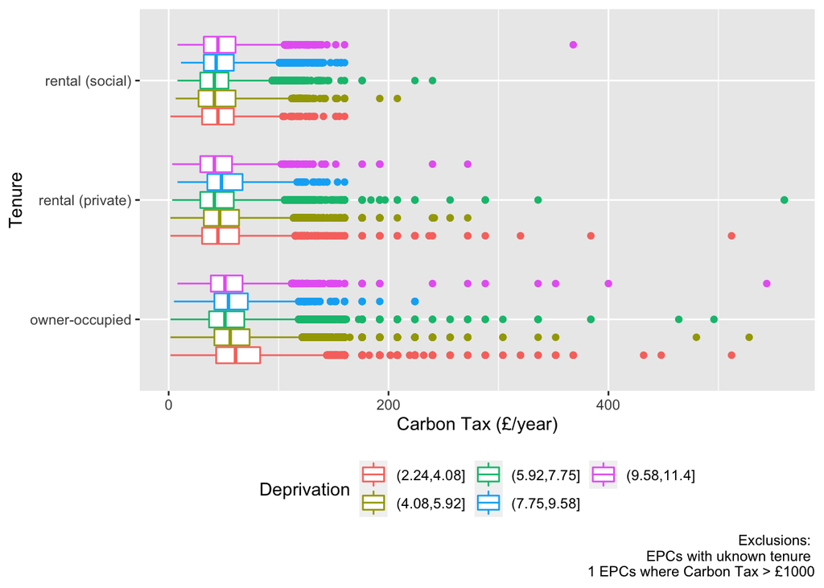

Figure 5.5: Boxplot of dwelling level Carbon Tax by area deprivation level (% of households with 3 dimensions of deprivation)

```r
epcDT[, dep3_cuts := cut(dep3_pc, 5)]

plotDT <- epcDT[epcIsUnknownTenure != 1 & TENURE != "unknown" &
                  carbonTax < 1000 &
                  !is.na(dep3_cuts)]

myCaption <- paste0("Exclusions: \n",
                    "EPCs with uknown tenure \n",
                    nrow(epcDT[carbonTax > 1000]), " EPCs where Carbon Tax > £1000")

ggplot2::ggplot(plotDT, aes(x = carbonTax, y = TENURE, colour = dep3_cuts)) +
  geom_boxplot() +
  scale_color_discrete(name = "Deprivation") +
  theme(legend.position = "bottom") +
  guides(colour=guide_legend(nrow=2)) +
  labs(x = "Carbon Tax (£/year)",
       y = "Tenure",
       caption = myCaption)
```

```r
t <- table(epcDT$TENURE, epcDT$dep3_cuts, useNA = "always")
kableExtra::kable(addmargins(t), caption = "Frequency counts of EPCs by Tenure and MSOA deprivation") %>%
  kable_styling()
```

Table 5.3: Frequency counts of EPCs by Tenure and MSOA deprivation

|  | (2.24,4.08] | (4.08,5.92] | (5.92,7.75] | (7.75,9.58] | (9.58,11.4] | NA | Sum |
| --- | --- | --- | --- | --- | --- | --- | --- |
|  | 156 | 839 | 627 | 189 | 89 | 5 | 1905 |
| NO DATA! | 48 | 272 | 402 | 50 | 139 | 0 | 911 |
| owner-occupied | 7284 | 8607 | 8740 | 1955 | 2778 | 9 | 29373 |
| rental (private) | 4311 | 5416 | 7341 | 555 | 1785 | 3 | 19411 |
| rental (social) | 1177 | 2671 | 4721 | 2616 | 3543 | 0 | 14728 |
| unknown | 703 | 1615 | 2088 | 214 | 499 | 55 | 5174 |
| NA | 0 | 0 | 0 | 0 | 0 | 0 | 0 |
| Sum | 13679 | 19420 | 23919 | 5579 | 8833 | 72 | 71502 |

Figure 5.5 suggest that in general owner-occupied dwellings will be liable for a higher Carbon Tax charge (compare across Tenure). In addition owner-occupied dwellings in areas with lower deprivation would generally pay slightly more.

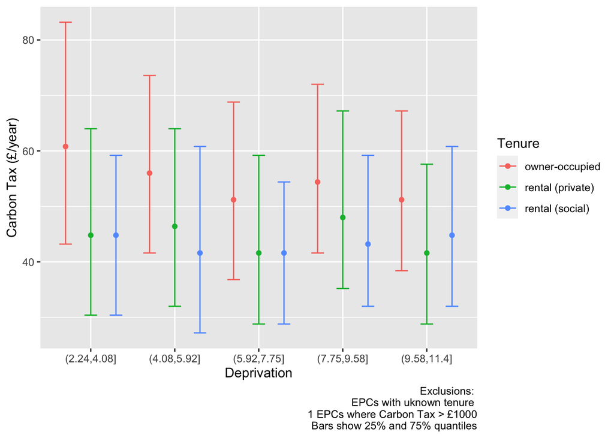

Figure 5.6: Median Carbon Tax by tenure and deprivation level

```r
aggDT <- plotDT[, .(median = median(carbonTax),
                    p25 = quantile(carbonTax)[[2]],
                    p75 = quantile(carbonTax)[[4]]), keyby = .(TENURE, dep3_cuts)]

myCaption <- paste0(myCaption, "\nBars show 25% and 75% quantiles"
                    )

dodge <- position_dodge(width=0.9) # https://ggplot2.tidyverse.org/reference/geom_linerange.html
ggplot2::ggplot(aggDT, aes(x = dep3_cuts, y = median, colour = TENURE, group = TENURE)) +
  geom_point(position = dodge) +
  geom_errorbar(aes(ymin = p25, ymax = p75), position = dodge, width = 0.45)+
  scale_color_discrete(name = "Tenure") +
  labs(x = "Deprivation",
       y = "Carbon Tax (£/year)",
       caption = myCaption)
```

# 6 So what?

Several things are clear from these #backOfaFagPacket estimates:

Given that larger and wealthier households use more energy, a fixed rate Carbon Tax might be progressive but wealthier households would potentially have the capital to de-carbonise quicker. In addition social and private renters are not in a position to improve the fabric of their dwelling and so it seems unfair to penalise them for living in low energy efficiency dwellings. In this situation we might need to distinguish between unavoidable emissions (due to the built form) and avoidable ones due to occupant practices). This might open up a right [can of worms](https://idioms.thefreedictionary.com/can+of+worms)…

# 7 R packages used

- rmarkdown (Allaire et al. 2018)
- bookdown (Xie 2016a)
- knitr (Xie 2016b)
- data.table (Dowle et al. 2015)
- ggplot2 (Wickham 2009)
- kableExtra (Zhu 2018)
- readxl (Wickham and Bryan 2017)

# References

Allaire, JJ, Yihui Xie, Jonathan McPherson, Javier Luraschi, Kevin Ushey, Aron Atkins, Hadley Wickham, Joe Cheng, and Winston Chang. 2018. *Rmarkdown: Dynamic Documents for R*. https://CRAN.R-project.org/package=rmarkdown.

Dowle, M, A Srinivasan, T Short, S Lianoglou with contributions from R Saporta, and E Antonyan. 2015. *Data.table: Extension of Data.frame*. https://CRAN.R-project.org/package=data.table.

Wickham, Hadley. 2009. *Ggplot2: Elegant Graphics for Data Analysis*. Springer-Verlag New York. http://ggplot2.org.

Wickham, Hadley, and Jennifer Bryan. 2017. *Readxl: Read Excel Files*. https://CRAN.R-project.org/package=readxl.

Xie, Yihui. 2016a. *Bookdown: Authoring Books and Technical Documents with R Markdown*. Boca Raton, Florida: Chapman; Hall/CRC. https://github.com/rstudio/bookdown.

———. 2016b. *Knitr: A General-Purpose Package for Dynamic Report Generation in R*. https://CRAN.R-project.org/package=knitr.

Zhu, Hao. 2018. *KableExtra: Construct Complex Table with ’Kable’ and Pipe Syntax*. https://CRAN.R-project.org/package=kableExtra.